# Module Three Project

ABRACA - DATA

1/25/2021

# Advertisement

## 1. Defining the question

### a) Specifying the Question

To estimate the probability of default payment by a credit card client based on the historical data provided using supervised and unsupervised machine learning models.

### b) Defining the Metric for Success

The analysis will be considered a success when interactive visualizations that tell a good story are achieved. An all-round Exploratory data analysis is achieved and a powerful supervised and unsupervised predictive model will be considered a success by the help of the confusion matrix

### c) Understanding the context

Credit card default happens when a customer becomes severely delinquent on their credit card payments say if a client misses the minimum payment six months in a row, then the credit card will be in default and the bank will more than likely close the account. For lenders, an increase in credit card delinquencies is an expensive proposition, since the more delinquent an account becomes, the smaller the chance it will be repaid at all. Therefore predicting delinquencies is an important objective for these lending institutions.

### d) Recording the Experimental Design

1. Importing the data set
2. Data Understanding
3. Performing Data Cleaning
4. Performing EDA
5. Building a Supervised Learning Model : A classification Model.
6. Building an Unsupervised Learning model while applying dimensionality reduction techniques : Clustering Model with K-Means and DBSCAN Clustering.
7. Providing Recommendations and Insights based on our findings.

### e) Data Relevance

The datasets are large enough to be used for Exploratory Data Analysis and for the modeling purposes, thus promising better outcomes.

### f) Reading the Data

```r
library(ggplot2)
library(tidyverse)
library(readxl)
defaulters <- read_excel("C:/Users/ALLANOOH/Documents/moringa/R/IP's/ABRACA -DATA/default of credit card clients.xls")
```

## 2. Data Understanding

```r
str(defaulters)
```

```
## tibble [30,000 x 25] (S3: tbl_df/tbl/data.frame)
##  $ ID                        : num [1:30000] 1 2 3 4 5 6 7 8 9 10 ...
##  $ LIMIT_BAL                 : num [1:30000] 20000 120000 90000 50000 50000 50000 500000 100000 140000 20000 ...
##  $ SEX                       : num [1:30000] 2 2 2 2 1 1 1 2 2 1 ...
##  $ EDUCATION                 : num [1:30000] 2 2 2 2 2 1 1 2 3 3 ...
##  $ MARRIAGE                  : num [1:30000] 1 2 2 1 1 2 2 2 1 2 ...
##  $ AGE                       : num [1:30000] 24 26 34 37 57 37 29 23 28 35 ...
##  $ PAY_0                     : num [1:30000] 2 -1 0 0 -1 0 0 0 0 -2 ...
##  $ PAY_2                     : num [1:30000] 2 2 0 0 0 0 0 -1 0 -2 ...
##  $ PAY_3                     : num [1:30000] -1 0 0 0 -1 0 0 -1 2 -2 ...
##  $ PAY_4                     : num [1:30000] -1 0 0 0 0 0 0 0 0 -2 ...
##  $ PAY_5                     : num [1:30000] -2 0 0 0 0 0 0 0 0 -1 ...
##  $ PAY_6                     : num [1:30000] -2 2 0 0 0 0 0 -1 0 -1 ...
##  $ BILL_AMT1                 : num [1:30000] 3913 2682 29239 46990 8617 ...
##  $ BILL_AMT2                 : num [1:30000] 3102 1725 14027 48233 5670 ...
##  $ BILL_AMT3                 : num [1:30000] 689 2682 13559 49291 35835 ...
##  $ BILL_AMT4                 : num [1:30000] 0 3272 14331 28314 20940 ...
##  $ BILL_AMT5                 : num [1:30000] 0 3455 14948 28959 19146 ...
##  $ BILL_AMT6                 : num [1:30000] 0 3261 15549 29547 19131 ...
##  $ PAY_AMT1                  : num [1:30000] 0 0 1518 2000 2000 ...
##  $ PAY_AMT2                  : num [1:30000] 689 1000 1500 2019 36681 ...
##  $ PAY_AMT3                  : num [1:30000] 0 1000 1000 1200 10000 657 38000 0 432 0 ...
##  $ PAY_AMT4                  : num [1:30000] 0 1000 1000 1100 9000 ...
##  $ PAY_AMT5                  : num [1:30000] 0 0 1000 1069 689 ...
##  $ PAY_AMT6                  : num [1:30000] 0 2000 5000 1000 679 ...
##  $ default payment next month: num [1:30000] 1 1 0 0 0 0 0 0 0 0 ...
```

Our dataset is comprised of numeric variables

```r
# previewing the dataset
glimpse(defaulters)
```

```
## Rows: 30,000
## Columns: 25
## $ ID                           <dbl> 1, 2, 3, 4, 5, 6, 7, 8, 9, 10, 11, 12,...
## $ LIMIT_BAL                    <dbl> 20000, 120000, 90000, 50000, 50000, 50...
## $ SEX                          <dbl> 2, 2, 2, 2, 1, 1, 1, 2, 2, 1, 2, 2, 2,...
## $ EDUCATION                    <dbl> 2, 2, 2, 2, 2, 1, 1, 2, 3, 3, 3, 1, 2,...
## $ MARRIAGE                     <dbl> 1, 2, 2, 1, 1, 2, 2, 2, 1, 2, 2, 2, 2,...
## $ AGE                          <dbl> 24, 26, 34, 37, 57, 37, 29, 23, 28, 35...
## $ PAY_0                        <dbl> 2, -1, 0, 0, -1, 0, 0, 0, 0, -2, 0, -1...
## $ PAY_2                        <dbl> 2, 2, 0, 0, 0, 0, 0, -1, 0, -2, 0, -1,...
## $ PAY_3                        <dbl> -1, 0, 0, 0, -1, 0, 0, -1, 2, -2, 2, -...
## $ PAY_4                        <dbl> -1, 0, 0, 0, 0, 0, 0, 0, 0, -2, 0, -1,...
## $ PAY_5                        <dbl> -2, 0, 0, 0, 0, 0, 0, 0, 0, -1, 0, -1,...
## $ PAY_6                        <dbl> -2, 2, 0, 0, 0, 0, 0, -1, 0, -1, -1, 2...
## $ BILL_AMT1                    <dbl> 3913, 2682, 29239, 46990, 8617, 64400,...
## $ BILL_AMT2                    <dbl> 3102, 1725, 14027, 48233, 5670, 57069,...
## $ BILL_AMT3                    <dbl> 689, 2682, 13559, 49291, 35835, 57608,...
## $ BILL_AMT4                    <dbl> 0, 3272, 14331, 28314, 20940, 19394, 5...
## $ BILL_AMT5                    <dbl> 0, 3455, 14948, 28959, 19146, 19619, 4...
## $ BILL_AMT6                    <dbl> 0, 3261, 15549, 29547, 19131, 20024, 4...
## $ PAY_AMT1                     <dbl> 0, 0, 1518, 2000, 2000, 2500, 55000, 3...
## $ PAY_AMT2                     <dbl> 689, 1000, 1500, 2019, 36681, 1815, 40...
## $ PAY_AMT3                     <dbl> 0, 1000, 1000, 1200, 10000, 657, 38000...
## $ PAY_AMT4                     <dbl> 0, 1000, 1000, 1100, 9000, 1000, 20239...
## $ PAY_AMT5                     <dbl> 0, 0, 1000, 1069, 689, 1000, 13750, 16...
## $ PAY_AMT6                     <dbl> 0, 2000, 5000, 1000, 679, 800, 13770, ...
## $ `default payment next month` <dbl> 1, 1, 0, 0, 0, 0, 0, 0, 0, 0, 0, 0, 0,...
```

There are 25 variables:

1. ID: ID of each client
2. LIMIT_BAL: Amount of given credit in NT dollars (includes individual and family/supplementary credit
3. SEX: Gender (1=male, 2=female)
4. EDUCATION: (1=graduate school, 2=university, 3=high school, 4=others, 5=unknown, 6=unknown)
5. MARRIAGE: Marital status (1=married, 2=single, 3=others)
6. AGE: Age in years
7. PAY_0: Repayment status in September, 2005 (0=pay duly, 1=payment delay for one month, 2=payment delay for two months, … 8=payment delay for eight months, 9=payment delay for nine months and above)
8. PAY_2: Repayment status in August, 2005 (scale same as above)
9. PAY_3: Repayment status in July, 2005 (scale same as above)
10. PAY_4: Repayment status in June, 2005 (scale same as above)
11. PAY_5: Repayment status in May, 2005 (scale same as above)
12. PAY_6: Repayment status in April, 2005 (scale same as above)
13. BILL_AMT1: Amount of bill statement in September, 2005 (NT dollar)
14. BILL_AMT2: Amount of bill statement in August, 2005 (NT dollar)
15. BILL_AMT3: Amount of bill statement in July, 2005 (NT dollar)
16. BILL_AMT4: Amount of bill statement in June, 2005 (NT dollar)
17. BILL_AMT5: Amount of bill statement in May, 2005 (NT dollar)
18. BILL_AMT6: Amount of bill statement in April, 2005 (NT dollar)
19. PAY_AMT1: Amount of previous payment in September, 2005 (NT dollar)
20. PAY_AMT2: Amount of previous payment in August, 2005 (NT dollar)
21. PAY_AMT3: Amount of previous payment in July, 2005 (NT dollar)
22. PAY_AMT4: Amount of previous payment in June, 2005 (NT dollar)
23. PAY_AMT5: Amount of previous payment in May, 2005 (NT dollar)
24. PAY_AMT6: Amount of previous payment in April, 2005 (NT dollar)
25. default.payment.next.month: Default payment (1=yes, 0=no)

## 3. Data Cleaning

We dropped the ID column from the dataset as it was a redundant column.

```r
# dropping the id
defaulters <- subset(defaulters, select = -c(ID))
dim(defaulters)
```

```
## [1] 30000    24
```

```r
head(defaulters)
```

```
## # A tibble: 6 x 24
##   LIMIT_BAL   SEX EDUCATION MARRIAGE   AGE PAY_0 PAY_2 PAY_3 PAY_4 PAY_5 PAY_6
##       <dbl> <dbl>     <dbl>    <dbl> <dbl> <dbl> <dbl> <dbl> <dbl> <dbl> <dbl>
## 1     20000     2         2        1    24     2     2    -1    -1    -2    -2
## 2    120000     2         2        2    26    -1     2     0     0     0     2
## 3     90000     2         2        2    34     0     0     0     0     0     0
## 4     50000     2         2        1    37     0     0     0     0     0     0
## 5     50000     1         2        1    57    -1     0    -1     0     0     0
## 6     50000     1         1        2    37     0     0     0     0     0     0
## # ... with 13 more variables: BILL_AMT1 <dbl>, BILL_AMT2 <dbl>,
## #   BILL_AMT3 <dbl>, BILL_AMT4 <dbl>, BILL_AMT5 <dbl>, BILL_AMT6 <dbl>,
## #   PAY_AMT1 <dbl>, PAY_AMT2 <dbl>, PAY_AMT3 <dbl>, PAY_AMT4 <dbl>,
## #   PAY_AMT5 <dbl>, PAY_AMT6 <dbl>, `default payment next month` <dbl>
```

```r
# checking for the null values
sum(is.na(defaulters))
```

```
## [1] 0
```

There were no null values identified

```r
# checking for the duplicated values

sum(duplicated(defaulters))
```

```
## [1] 35
```

35 duplicated values were observed and dropped

```r
# dropping the duplicated values

def <- distinct(defaulters)

# confirming if the duplicated valued were removed

sum(duplicated(def))
```

```
## [1] 0
```

```r
# Renaming column default payment next month where they have spaces in between.
names(def)[names(def) == "default payment next month"] <- "default_payment_next_month"

head(def)
```

```
## # A tibble: 6 x 24
##   LIMIT_BAL   SEX EDUCATION MARRIAGE   AGE PAY_0 PAY_2 PAY_3 PAY_4 PAY_5 PAY_6
##       <dbl> <dbl>     <dbl>    <dbl> <dbl> <dbl> <dbl> <dbl> <dbl> <dbl> <dbl>
## 1     20000     2         2        1    24     2     2    -1    -1    -2    -2
## 2    120000     2         2        2    26    -1     2     0     0     0     2
## 3     90000     2         2        2    34     0     0     0     0     0     0
## 4     50000     2         2        1    37     0     0     0     0     0     0
## 5     50000     1         2        1    57    -1     0    -1     0     0     0
## 6     50000     1         1        2    37     0     0     0     0     0     0
## # ... with 13 more variables: BILL_AMT1 <dbl>, BILL_AMT2 <dbl>,
## #   BILL_AMT3 <dbl>, BILL_AMT4 <dbl>, BILL_AMT5 <dbl>, BILL_AMT6 <dbl>,
## #   PAY_AMT1 <dbl>, PAY_AMT2 <dbl>, PAY_AMT3 <dbl>, PAY_AMT4 <dbl>,
## #   PAY_AMT5 <dbl>, PAY_AMT6 <dbl>, default_payment_next_month <dbl>
```

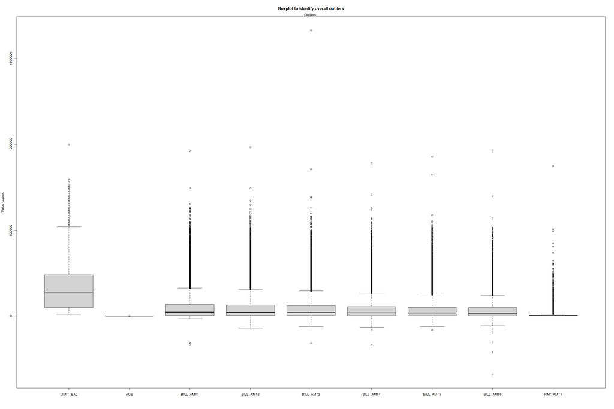

```r
# checking for outliers
#
# selecting the continous variables
split_1 <- subset(def, select = c(LIMIT_BAL, AGE, BILL_AMT1, BILL_AMT2, BILL_AMT3, BILL_AMT4,
                                  BILL_AMT5, BILL_AMT6, PAY_AMT1))

# plotting for the selected variables
boxplot(split_1,
  ylab = "Value counts",
  main = "Boxplot to identify overall outliers"
)
mtext(paste("Outliers: "))
```

From the boxplot we can observe there is the presence of outliers in the dataset. The outliers will not be removed so as to identify if there are patterns in the dataset.

## 4. Exploratory Data Analysis

### a) Univariate Data Analysis

#### Countplots for the Categorical Variables.

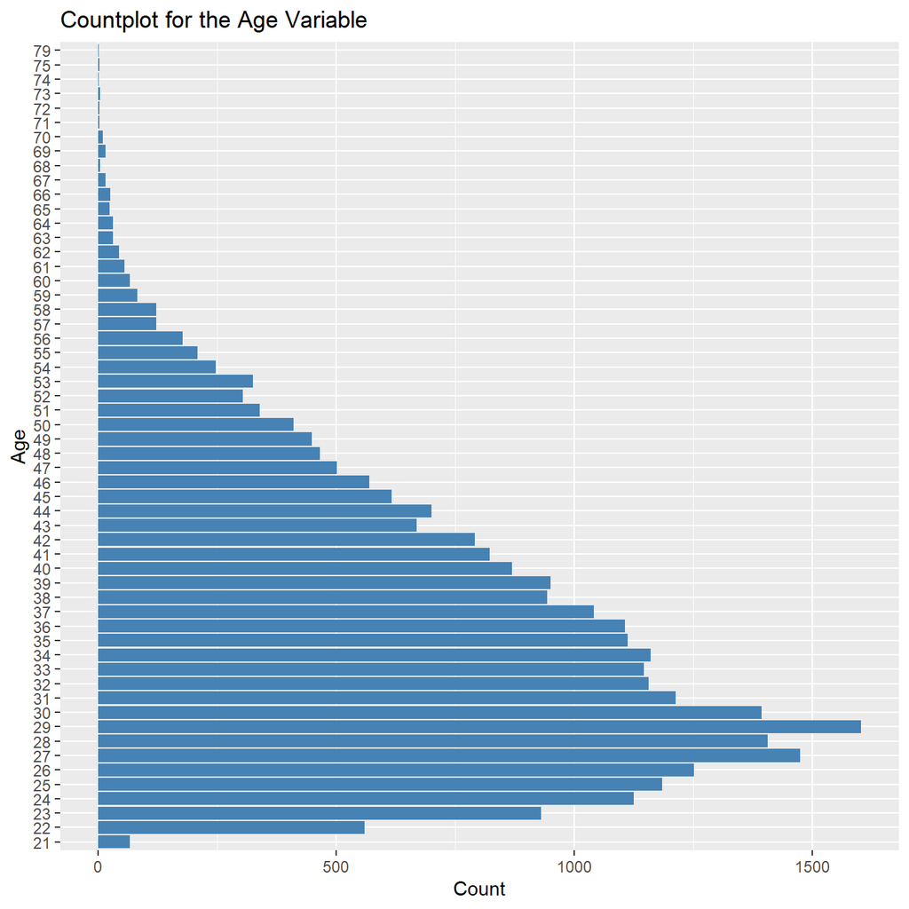

```r
# count plot for the age column
ggplot(def, aes(as.factor(x=AGE))) + geom_bar(fill= "steelblue")+labs(title='Countplot for the Age Variable' , x ='Age' , y = 'Count')+coord_flip()
```

Most of the clients who obtain the credit cards are the youths aged between 25 to 40 years

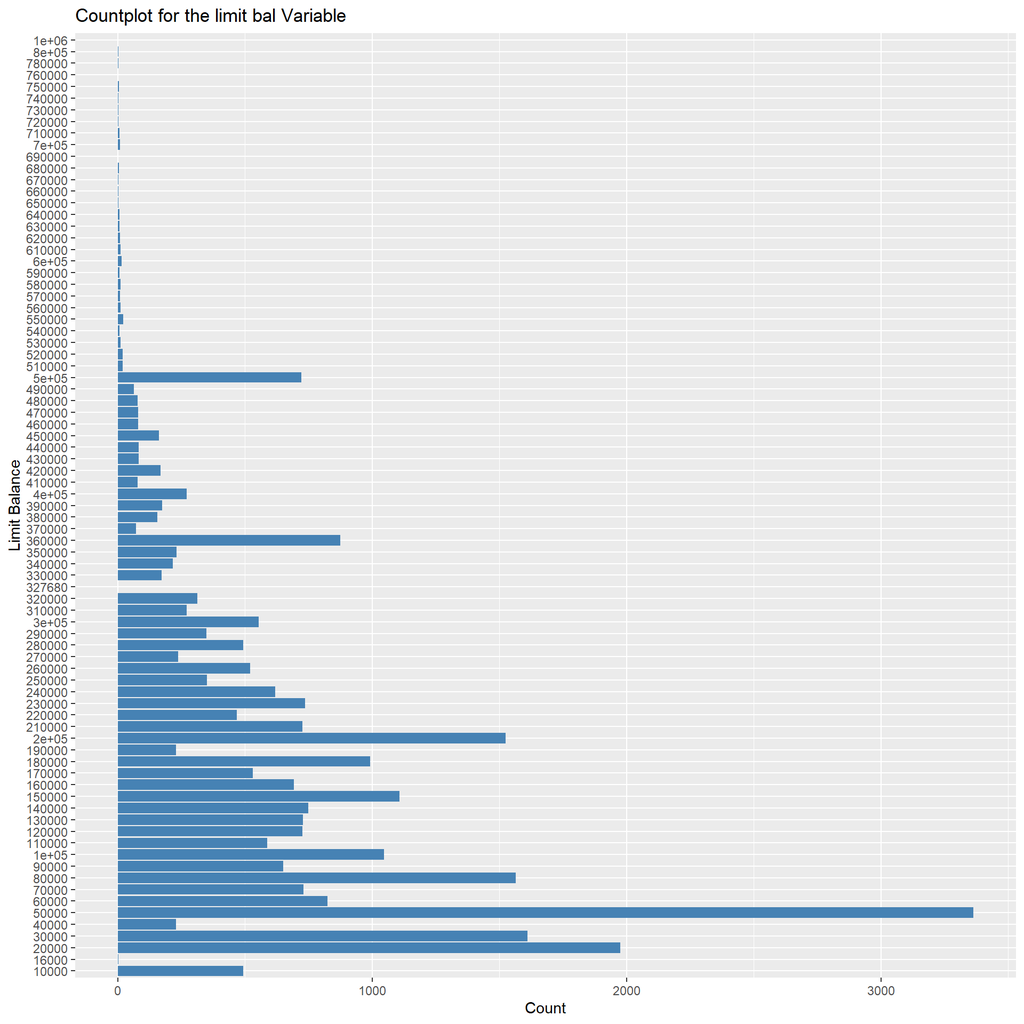

```r
# count plot for the limit bal column

ggplot(def, aes(as.factor(x= LIMIT_BAL))) + geom_histogram(fill= "steelblue" , stat="count" , bins = 10)+labs(title='Countplot for the limit bal Variable' , x ='Limit Balance' , y = 'Count')+coord_flip()
```

##### Gender

(1 = male; 2 = female)

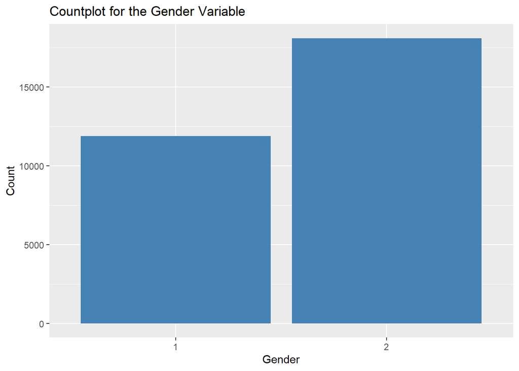

```r
# plotting for the gender column
ggplot(def, aes(as.factor(x=SEX))) + geom_bar(fill= "steelblue")+labs(title='Countplot for the Gender Variable' , x ='Gender' , y = 'Count')
```

Females happen to be the ones who take most credit cards over the period of time

#### The Education Variable

(1 = graduate school; 2 = university; 3 = high school; 4 = others)

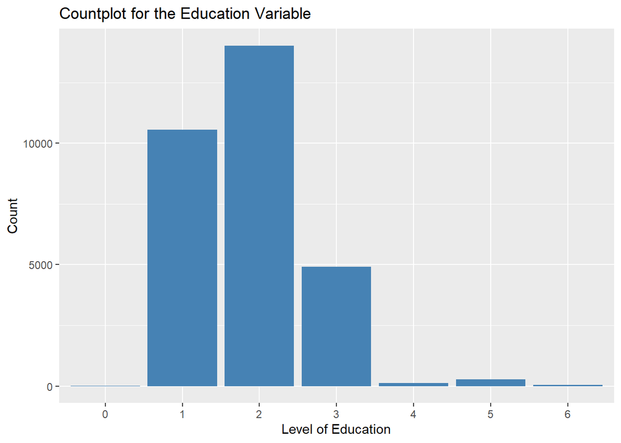

```r
ggplot(def, aes(as.factor(x=EDUCATION))) + geom_bar(fill= "steelblue")+labs(title='Countplot for the Education Variable' , x ='Level of Education' , y = 'Count')
```

Most of the clients who take credit cars are those fromwith the education level of university and graduate high school

#### Marriage

(1 = married; 2 = single; 3 = others)

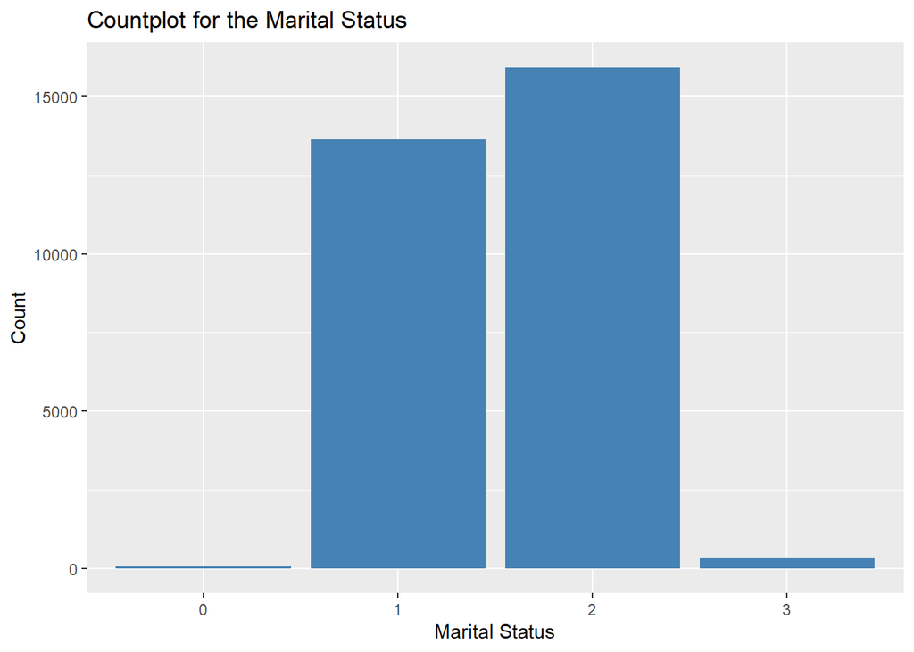

```r
ggplot(def, aes(as.factor(x=MARRIAGE))) + geom_bar(fill= "steelblue")+labs(title='Countplot for the Marital Status' , x ='Marital Status', y = 'Count')
```

Most of the clients who happen to take credit cards are the singles followed by the married

#### History of Past Payments Variables

Past monthly payment records (from April to September, 2005) as follows: PAY_0 = the repayment status in September, 2005; PAY_1 = the repayment status in August, 2005; . . .; PAY_6 = the repayment status in April, 2005.

The measurement scale for the repayment status is: + 0 = pay duly; + 1 = payment delay for one month; + 2 = payment delay for two months; . . .; + 8 = payment delay for eight months; + 9 = payment delay for nine months and above.

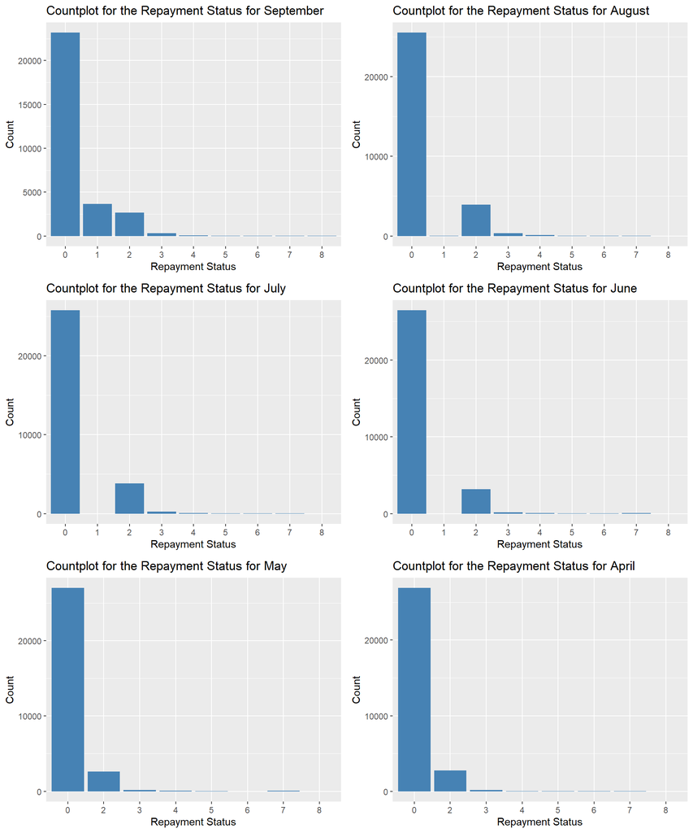

```r
library(ggpubr)

# combining -1 and -2 to 0 so as to sum up the amount paid duly
def$PAY_0[def$PAY_0 == -2 | def$PAY_0== -1] <- 0
def$PAY_2[def$PAY_2 == -2 | def$PAY_2== -1] <- 0
def$PAY_3[def$PAY_3 == -2 | def$PAY_3== -1] <- 0
def$PAY_4[def$PAY_4 == -2 | def$PAY_4== -1] <- 0
def$PAY_5[def$PAY_5 == -2 | def$PAY_5== -1] <- 0
def$PAY_6[def$PAY_6 == -2 | def$PAY_6== -1] <- 0

p1 <- ggplot(def, aes(as.factor(x=PAY_0))) + geom_bar(fill= "steelblue")+labs(title='Countplot for the Repayment Status for September' , x ='Repayment Status' , y = 'Count')



p2 <- ggplot(def, aes(as.factor(x=PAY_2))) + geom_bar(fill= "steelblue")+labs(title='Countplot for the Repayment Status for August' , x ='Repayment Status' , y = 'Count')

p3 <- ggplot(def, aes(as.factor(x=PAY_3))) + geom_bar(fill= "steelblue")+labs(title='Countplot for the Repayment Status for July' , x ='Repayment Status' , y = 'Count')

p4<- ggplot(def, aes(as.factor(x=PAY_4))) + geom_bar(fill= "steelblue")+labs(title='Countplot for the Repayment Status for June' , x ='Repayment Status' , y = 'Count')


p5 <- ggplot(def, aes(as.factor(x=PAY_5))) + geom_bar(fill= "steelblue")+labs(title='Countplot for the Repayment Status for May' , x ='Repayment Status' , y = 'Count')

p6 <- ggplot(def , aes(as.factor(x=PAY_6))) + geom_bar(fill= "steelblue")+labs(title='Countplot for the Repayment Status for April' , x ='Repayment Status' , y = 'Count')

figure <- ggarrange(p1, p2, p3,p4,p5,p6,
                  ncol = 2, nrow = 3)
figure
```